# Gain and Loss Final Models

This is a cleaned version of 04_24_19 Temp link trait fish.Rmd/11_20_19_Temp_link_traits_fish.Rmd. Changes * improved formatting * easier to follow * species and region as random effects * scaling temperature values * setting nACQ to 0, see why [here](https://stats.stackexchange.com/questions/77313/why-cant-i-match-glmmTMB-family-binomial-output-with-manual-implementation-of-g).

August 11, 2022: Working on Revisions from Global Ecology and Biogeography * Add random effects for order, genus, family, etc.

```r
library(MuMIn)
library(lme4)
library(data.table)
library(ggplot2)
library(here)
library(wesanderson) # to color plots
library(taxize) #to obtain order, genus, family
library(dplyr)
library(DHARMa)

spp_master_ztemp_seus_buoy_scaled <- readRDS(here::here("Data","Spp_master", "spp_master_ztemp_seus_buoy_scaled.rds"))
```

Link up with spp key to add phylum, order, family, etc. *Be careful not to run this more than once, or it will keep deleting more years

```r
spp_key <- fread(here::here("Data","Spp_master","spp_key.csv")) #bring in list of species with phylogenetic classifications

#merge with spp_master
spp_master_ztemp_seus_buoy_scaled <- spp_key[spp_master_ztemp_seus_buoy_scaled, on = "spp", nomatch = NULL]

#delete first year each region is sampled (because gains and losses are based on transitions between years, so we need 2 years of observations)

spp_master_ztemp_seus_buoy_scaled[,min_year := min(year),.(reg)]

spp_master_ztemp_seus_buoy_scaled <- spp_master_ztemp_seus_buoy_scaled[year != min_year]

nrow(spp_master_ztemp_seus_buoy_scaled) == 17997
```

*^check, is spp_master 17997 rows (down from 18856)?

Edit column names for understanding

```r
spp_master_ztemp_seus_buoy_scaled[,gain :=col][,loss := now_ext]
```

Running, and ranking gain models without traits

##Here, I scaled all temperature values across all regions, and included species as a random effect. In order to do this, I had to change the algorithm slightly–nAGQ = 0.

Gain Models with Additional random effects

```r
variables_scaled <- grep("*_scaled", names(spp_master_ztemp_seus_buoy_scaled), value = T)
#going to make loop to make all models I need to look at with a single temperature variable

#we don't end up looking at mean, delete here
variables_scaled <- variables_scaled[-grep('mean',variables_scaled)]

gain_model_comparison_taxonomy <- as.data.table(matrix(nrow = length(variables_scaled)))
gain_model_comparison_taxonomy[, variable:=as.factor(V1)][, coef:=as.numeric(V1)][, p_value:=as.numeric(V1)][, conditional_R2 := as.numeric(V1)][,marginal_R2 := as.numeric(V1)][, AICc:=as.numeric(V1)]
gain_model_comparison_taxonomy[, V1 := NULL]

for (i in 1:length(variables_scaled)){
  mod <- glmer(gain ~ get(variables_scaled[i]) + (1|reg) + (1|phylum) + (1|class) + (1|order) + (1|family) + (1|genus) + (1|spp),
               family = binomial, data = spp_master_ztemp_seus_buoy_scaled, nAGQ = 0)

  rsquared <- r.squaredGLMM(mod)

  gain_model_comparison_taxonomy[i,variable := variables_scaled[i]]
  gain_model_comparison_taxonomy[i,coef := coef(summary(mod))[,"Estimate"][2]]
  gain_model_comparison_taxonomy[i,p_value := coef(summary(mod))[,"Pr(>|z|)"][2]]
  gain_model_comparison_taxonomy[i,conditional_R2 := rsquared[2,2]]
  gain_model_comparison_taxonomy[i,marginal_R2 := rsquared[2,1]]
  gain_model_comparison_taxonomy[i,AICc := AICc(mod)]

  print(paste(i, length(variables_scaled), sep = "/"))

}
```

[output not shown]

```
[1] "1/186"
```

[output not shown]

```
[1] "2/186"
```

[output not shown]

```
[1] "3/186"
```

[output not shown]

```
[1] "4/186"
```

[output not shown]

```
[1] "5/186"
```

[output not shown]

```
[1] "6/186"
```

[output not shown]

```
[1] "7/186"
```

[output not shown]

```
[1] "8/186"
```

[output not shown]

```
[1] "9/186"
```

[output not shown]

```
[1] "10/186"
```

[output not shown]

```
[1] "11/186"
```

[output not shown]

```
[1] "12/186"
```

[output not shown]

```
[1] "13/186"
```

[output not shown]

```
[1] "14/186"
```

[output not shown]

```
[1] "15/186"
```

[output not shown]

```
[1] "16/186"
```

[output not shown]

```
[1] "17/186"
```

[output not shown]

```
[1] "18/186"
```

[output not shown]

```
[1] "19/186"
```

[output not shown]

```
[1] "20/186"
```

[output not shown]

```
[1] "21/186"
```

[output not shown]

```
[1] "22/186"
```

[output not shown]

```
[1] "23/186"
```

[output not shown]

```
[1] "24/186"
```

[output not shown]

```
[1] "25/186"
```

[output not shown]

```
[1] "26/186"
```

[output not shown]

```
[1] "27/186"
```

[output not shown]

```
[1] "28/186"
```

[output not shown]

```
[1] "29/186"
```

[output not shown]

```
[1] "30/186"
```

[output not shown]

```
[1] "31/186"
```

[output not shown]

```
[1] "32/186"
```

[output not shown]

```
[1] "33/186"
```

[output not shown]

```
[1] "34/186"
```

[output not shown]

```
[1] "35/186"
```

[output not shown]

```
[1] "36/186"
```

[output not shown]

```
[1] "37/186"
```

[output not shown]

```
[1] "38/186"
```

[output not shown]

```
[1] "39/186"
```

[output not shown]

```
[1] "40/186"
```

[output not shown]

```
[1] "41/186"
```

[output not shown]

```
[1] "42/186"
```

[output not shown]

```
[1] "43/186"
```

[output not shown]

```
[1] "44/186"
```

[output not shown]

```
[1] "45/186"
```

[output not shown]

```
[1] "46/186"
```

[output not shown]

```
[1] "47/186"
```

[output not shown]

```
[1] "48/186"
```

[output not shown]

```
[1] "49/186"
```

[output not shown]

```
[1] "50/186"
```

[output not shown]

```
[1] "51/186"
```

[output not shown]

```
[1] "52/186"
```

[output not shown]

```
[1] "53/186"
```

[output not shown]

```
[1] "54/186"
```

[output not shown]

```
[1] "55/186"
```

[output not shown]

```
[1] "56/186"
```

[output not shown]

```
[1] "57/186"
```

[output not shown]

```
[1] "58/186"
```

[output not shown]

```
[1] "59/186"
```

[output not shown]

```
[1] "60/186"
```

[output not shown]

```
[1] "61/186"
```

[output not shown]

```
[1] "62/186"
```

[output not shown]

```
[1] "63/186"
```

[output not shown]

```
[1] "64/186"
```

[output not shown]

```
[1] "65/186"
```

[output not shown]

```
[1] "66/186"
```

[output not shown]

```
[1] "67/186"
```

[output not shown]

```
[1] "68/186"
```

[output not shown]

```
[1] "69/186"
```

[output not shown]

```
[1] "70/186"
```

[output not shown]

```
[1] "71/186"
```

[output not shown]

```
[1] "72/186"
```

[output not shown]

```
[1] "73/186"
```

[output not shown]

```
[1] "74/186"
```

[output not shown]

```
[1] "75/186"
```

[output not shown]

```
[1] "76/186"
```

[output not shown]

```
[1] "77/186"
```

[output not shown]

```
[1] "78/186"
```

[output not shown]

```
[1] "79/186"
```

[output not shown]

```
[1] "80/186"
```

[output not shown]

```
[1] "81/186"
```

[output not shown]

```
[1] "82/186"
```

[output not shown]

```
[1] "83/186"
```

[output not shown]

```
[1] "84/186"
```

[output not shown]

```
[1] "85/186"
```

[output not shown]

```
[1] "86/186"
```

[output not shown]

```
[1] "87/186"
```

[output not shown]

```
[1] "88/186"
```

[output not shown]

```
[1] "89/186"
```

[output not shown]

```
[1] "90/186"
```

[output not shown]

```
[1] "91/186"
```

[output not shown]

```
[1] "92/186"
```

[output not shown]

```
[1] "93/186"
```

[output not shown]

```
[1] "94/186"
```

[output not shown]

```
[1] "95/186"
```

[output not shown]

```
[1] "96/186"
```

[output not shown]

```
[1] "97/186"
```

[output not shown]

```
[1] "98/186"
```

[output not shown]

```
[1] "99/186"
```

[output not shown]

```
[1] "100/186"
```

[output not shown]

```
[1] "101/186"
```

[output not shown]

```
[1] "102/186"
```

[output not shown]

```
[1] "103/186"
```

[output not shown]

```
[1] "104/186"
```

[output not shown]

```
[1] "105/186"
```

[output not shown]

```
[1] "106/186"
```

[output not shown]

```
[1] "107/186"
```

[output not shown]

```
[1] "108/186"
```

[output not shown]

```
[1] "109/186"
```

[output not shown]

```
[1] "110/186"
```

[output not shown]

```
[1] "111/186"
```

[output not shown]

```
[1] "112/186"
```

[output not shown]

```
[1] "113/186"
```

[output not shown]

```
[1] "114/186"
```

[output not shown]

```
[1] "115/186"
```

[output not shown]

```
[1] "116/186"
```

[output not shown]

```
[1] "117/186"
```

[output not shown]

```
[1] "118/186"
```

[output not shown]

```
[1] "119/186"
```

[output not shown]

```
[1] "120/186"
```

[output not shown]

```
[1] "121/186"
```

[output not shown]

```
[1] "122/186"
```

[output not shown]

```
[1] "123/186"
```

[output not shown]

```
[1] "124/186"
```

[output not shown]

```
[1] "125/186"
```

[output not shown]

```
[1] "126/186"
```

[output not shown]

```
[1] "127/186"
```

[output not shown]

```
[1] "128/186"
```

[output not shown]

```
[1] "129/186"
```

[output not shown]

```
[1] "130/186"
```

[output not shown]

```
[1] "131/186"
```

[output not shown]

```
[1] "132/186"
```

[output not shown]

```
[1] "133/186"
```

[output not shown]

```
[1] "134/186"
```

[output not shown]

```
[1] "135/186"
```

[output not shown]

```
[1] "136/186"
```

[output not shown]

```
[1] "137/186"
```

[output not shown]

```
[1] "138/186"
```

[output not shown]

```
[1] "139/186"
```

[output not shown]

```
[1] "140/186"
```

[output not shown]

```
[1] "141/186"
```

[output not shown]

```
[1] "142/186"
```

[output not shown]

```
[1] "143/186"
```

[output not shown]

```
[1] "144/186"
```

[output not shown]

```
[1] "145/186"
```

[output not shown]

```
[1] "146/186"
```

[output not shown]

```
[1] "147/186"
```

[output not shown]

```
[1] "148/186"
```

[output not shown]

```
[1] "149/186"
```

[output not shown]

```
[1] "150/186"
```

[output not shown]

```
[1] "151/186"
```

[output not shown]

```
[1] "152/186"
```

[output not shown]

```
[1] "153/186"
```

[output not shown]

```
[1] "154/186"
```

[output not shown]

```
[1] "155/186"
```

[output not shown]

```
[1] "156/186"
```

[output not shown]

```
[1] "157/186"
```

[output not shown]

```
[1] "158/186"
```

[output not shown]

```
[1] "159/186"
```

[output not shown]

```
[1] "160/186"
```

[output not shown]

```
[1] "161/186"
```

[output not shown]

```
[1] "162/186"
```

[output not shown]

```
[1] "163/186"
```

[output not shown]

```
[1] "164/186"
```

[output not shown]

```
[1] "165/186"
```

[output not shown]

```
[1] "166/186"
```

[output not shown]

```
[1] "167/186"
```

[output not shown]

```
[1] "168/186"
```

[output not shown]

```
[1] "169/186"
```

[output not shown]

```
[1] "170/186"
```

[output not shown]

```
[1] "171/186"
```

[output not shown]

```
[1] "172/186"
```

[output not shown]

```
[1] "173/186"
```

[output not shown]

```
[1] "174/186"
```

[output not shown]

```
[1] "175/186"
```

[output not shown]

```
[1] "176/186"
```

[output not shown]

```
[1] "177/186"
```

[output not shown]

```
[1] "178/186"
```

[output not shown]

```
[1] "179/186"
```

[output not shown]

```
[1] "180/186"
```

[output not shown]

```
[1] "181/186"
```

[output not shown]

```
[1] "182/186"
```

[output not shown]

```
[1] "183/186"
```

[output not shown]

```
[1] "184/186"
```

[output not shown]

```
[1] "185/186"
```

[output not shown]

```
[1] "186/186"
```

```r
#2nd best
mod_extrarandom_gain_2 <- glmer(gain ~ max_sst_temp_lag10_scaled  + (1|reg) + (1|phylum) + (1|class) + (1|order) + (1|family) + (1|genus) + (1|spp), family = binomial, data = spp_master_ztemp_seus_buoy_scaled, nAGQ = 0)
```

```
boundary (singular) fit: see help('isSingular')
```

```r
#3rd best
mod_extrarandom_gain_3 <- glmer(gain ~ seas_sst_temp_lag5_scaled  + (1|reg) + (1|phylum) + (1|class) + (1|order) + (1|family) + (1|genus) + (1|spp), family = binomial, data = spp_master_ztemp_seus_buoy_scaled, nAGQ = 0)
```

```
boundary (singular) fit: see help('isSingular')
```

```r
#4th best
mod_extrarandom_gain_4 <- glmer(gain ~ max_sst_temp_lag8_scaled  + (1|reg) + (1|phylum) + (1|class) + (1|order) + (1|family) + (1|genus) + (1|spp), family = binomial, data = spp_master_ztemp_seus_buoy_scaled, nAGQ = 0)
```

```
boundary (singular) fit: see help('isSingular')
```

Confidence intervals

```r
fixef(mod_extrarandom_gain)[2]-gain_confint[9,1]
```

```
seas_sst_temp_scaled
           0.2086744
```

```r
fixef(mod_extrarandom_gain_2)[2]-gain_confint_2[9,1]
```

```
max_sst_temp_lag10_scaled
                0.3152176
```

```r
fixef(mod_extrarandom_gain_3)[2]-gain_confint_3[9,1]
```

```
seas_sst_temp_lag5_scaled
                0.1697169
```

```r
fixef(mod_extrarandom_gain_4)[2]-gain_confint_4[9,1]
```

```
max_sst_temp_lag8_scaled
               0.3137837
```

“The estimate for seasonality of -0.52 means that a 1 degree increase in seasonality is associated with a 0.52 decrease in the log-odds of a Gain occuring, compared to no Gain occuring. If we exponentiate this number then we obtain the odds ratio of 0.59, which means that for a 1 degree increase in Seasonality we expect to see (approximately) a 41% decrease in the odds of a Gain Occurring.” From this [Stack Exchange post](https://stats.stackexchange.com/questions/444797/interpreting-a-generalised-linear-mixed-model-with-binomial-data).

###Loss Models without Traits but with random effects for phylogeny

```r
r.squaredGLMM(mod_extrarandom_loss)
```

```
                   R2m       R2c
theoretical 0.04446483 0.5042519
delta       0.01527950 0.1732767
```

Confidence intervals

```r
fixef(mod_extrarandom_loss)[2]-loss_confint_1[9,1]
```

```
seas_sst_temp_lag3_scaled
                0.1919406
```

```r
fixef(mod_extrarandom_loss_2)[2]-loss_confint_2[9,1]
```

```
max_sst_temp_change_abs_lag1_scaled
                          0.0945207
```

```r
fixef(mod_extrarandom_loss_3)[2]-loss_confint_3[9,1]
```

```
seas_sst_temp_lag2_scaled
                0.2142538
```

```r
fixef(mod_extrarandom_loss_4)[2]-loss_confint_4[9,1]
```

```
max_sst_temp_lag7_scaled
               0.3435602
```

##Relative Variable Importance

How does the null model with only random effects perform?

```r
#add to model summary tables
gain_null_row <- data.table(matrix(c(NA,NA,NA,r.squaredGLMM(intercept_gain_mod_scaled)[2,2],
                   r.squaredGLMM(intercept_gain_mod_scaled)[2,1],AICc(intercept_gain_mod_scaled)),nrow = 1))
loss_null_row <- data.table(matrix(c(NA,NA,NA,r.squaredGLMM(intercept_loss_mod_scaled)[2,2],
                   r.squaredGLMM(intercept_loss_mod_scaled)[2,1],AICc(intercept_loss_mod_scaled)),nrow = 1))
gain_model_comparison_taxonomy <- rbind(gain_model_comparison_taxonomy, gain_null_row, use.names = F)
loss_model_comparison_taxonomy <- rbind(loss_model_comparison_taxonomy, loss_null_row, use.names = F)
```

[output not shown]

Relative Variable Importance for Gain Models

```r
#add ∆AIC to tables
min_gain_AICc <- min(gain_model_comparison_taxonomy[, AICc])
gain_model_comparison_taxonomy[,"deltaAICc" := (AICc - min_gain_AICc)]

#add relative likelihood exp( -0.5 * ∆AIC score for that model)
gain_model_comparison_taxonomy[,"rel_likelihood" := exp((-0.5 * deltaAICc))]
#sum relative likelihoods across all models
gain_model_comparison_taxonomy.likelihoodsum <- sum(gain_model_comparison_taxonomy[, rel_likelihood])
#Akaike weight for a model is this rel_likelihood divided by the sum of these values across all models
gain_model_comparison_taxonomy[,"akaike_weight" := rel_likelihood/gain_model_comparison_taxonomy.likelihoodsum]

#I want to look at relative importance FOR:

#bottom/surface (bottom = includes sbt, grepl("sbt", variable))
gain_bottom_importance <- sum(gain_model_comparison_taxonomy[grep("sbt", variable), ]$akaike_weight)
gain_surface_importance <- sum(gain_model_comparison_taxonomy[grep("sst", variable), ]$akaike_weight)

#lag/not lagged (grepl("lag", variable))
gain_lag_importance <- sum(gain_model_comparison_taxonomy[grep("lag", variable), ]$akaike_weight)
gain_nolag_importance <- sum(gain_model_comparison_taxonomy[!grep("lag", variable), ]$akaike_weight)

#absolute (grepl("abs", variable))
gain_abs_importance <- sum(gain_model_comparison_taxonomy[grep("abs", variable), ]$akaike_weight)

#raw (!grepl("change"))
gain_raw_importance <- sum(gain_model_comparison_taxonomy[!grep("change", variable), ]$akaike_weight)

#change (grepl("change", variable), (!grepl("abs")))
gain_change_importance <- sum(gain_model_comparison_taxonomy[grep("change", variable), ][!grep("abs", variable),]$akaike_weight)

#type of temp variable (max, min, seas)
gain_max_temp_importance <- sum(gain_model_comparison_taxonomy[grep("max", variable), ]$akaike_weight)
gain_min_temp_importance <- sum(gain_model_comparison_taxonomy[grep("min", variable), ]$akaike_weight)
gain_seas_temp_importance <- sum(gain_model_comparison_taxonomy[grep("seas", variable), ]$akaike_weight)

gain_model_comparison_taxonomy_akaikeweights <- gain_model_comparison_taxonomy

saveRDS(gain_model_comparison_taxonomy_akaikeweights, file = here("Model_results","gain_model_comparison_taxonomy_akaikeweights.rds"))
saveRDS(gain_model_comparison_taxonomy_akaikeweights, file = here("tables","gain_model_comparison_taxonomy_akaikeweights.rds"))
gain_model_comparison_taxonomy_akaikeweights <- readRDS(file = here("Model_results","gain_model_comparison_taxonomy_akaikeweights.rds"))
```

Relative Variable Importance for different Pairs of Transformation and Metric

```r
#I want to look at relative importance FOR
#models with raw and min
gain_raw_min_importance <- sum(gain_model_comparison_taxonomy[grep("min", variable), ][!grep("change", variable)]$akaike_weight)

#models with raw and max
gain_raw_max_importance <- sum(gain_model_comparison_taxonomy[grep("max", variable), ][!grep("change", variable)]$akaike_weight)

#models with raw and seas
gain_raw_seas_importance <- sum(gain_model_comparison_taxonomy[grep("seas", variable), ][!grep("change", variable)]$akaike_weight)


#models with change and min
gain_change_min_importance <- sum(gain_model_comparison_taxonomy[grep("min_s.t_temp_change", variable), ][!grep("abs", variable)]$akaike_weight)

#models with change and max
gain_change_max_importance <- sum(gain_model_comparison_taxonomy[grep("max_s.t_temp_change", variable), ][!grep("abs", variable)]$akaike_weight)

#models with change and seas
gain_change_seas_importance <- sum(gain_model_comparison_taxonomy[grep("seas_s.t_temp_change", variable), ][!grep("abs", variable)]$akaike_weight)

#models with abs change and min
gain_abs_change_min_importance <- sum(gain_model_comparison_taxonomy[grep("min_s.t_temp_change_abs", variable), ]$akaike_weight)

#models with abs change and max
gain_abs_change_max_importance <- sum(gain_model_comparison_taxonomy[grep("max_s.t_temp_change_abs", variable), ]$akaike_weight)

#models with abs change and seas
gain_abs_change_seas_importance <- sum(gain_model_comparison_taxonomy[grep("seas_s.t_temp_change_abs", variable), ]$akaike_weight)

gain_transform_metric_comparison <- data.table(Transformation =
                                                c("raw", "raw", "raw", "change", "change", "change", "abs_change", "abs_change", "abs_change"),
                                              Metric =
                                                rep(c("min", "max", "seas"), 3),
                                              RVI =
                                                c(gain_raw_min_importance, gain_raw_max_importance,
                                                  gain_raw_seas_importance, gain_change_min_importance,
                                                  gain_change_max_importance, gain_change_seas_importance,
                                                  gain_abs_change_min_importance, gain_abs_change_max_importance,
                                                  gain_abs_change_seas_importance))
```

Relative Variable Importance Loss Models

```r
#add ∆AIC to tables
min_loss_AICc <- min(loss_model_comparison_taxonomy[, AICc])
loss_model_comparison_taxonomy[,"deltaAICc" := (AICc - min_loss_AICc)]

#add relative likelihood exp( -0.5 * ∆AIC score for that model)
loss_model_comparison_taxonomy[,"rel_likelihood" := exp((-0.5 * deltaAICc))]
#sum relative likelihoods across all models
loss_model_comparison_taxonomy.likelihoodsum <- sum(loss_model_comparison_taxonomy[, rel_likelihood])
#Akaike weight for a model is this rel_likelihood devided by the sum of these values across all models
loss_model_comparison_taxonomy[,"akaike_weight" := rel_likelihood/loss_model_comparison_taxonomy.likelihoodsum]

#I want to look at relative importance FOR
#bottom/surface (bottom = includes sbt, grepl("sbt", variable))
loss_bottom_importance <- sum(loss_model_comparison_taxonomy[grep("sbt", variable), ]$akaike_weight)
loss_surface_importance <- sum(loss_model_comparison_taxonomy[grep("sst", variable), ]$akaike_weight)

#lag/not lagged (grepl("lag", variable))
loss_lag_importance <- sum(loss_model_comparison_taxonomy[grep("lag", variable), ]$akaike_weight)
loss_nolag_importance <- sum(loss_model_comparison_taxonomy[!grep("lag", variable), ]$akaike_weight)

#absolute (grepl("abs", variable))
loss_abs_importance <- sum(loss_model_comparison_taxonomy[grep("abs", variable), ]$akaike_weight)

#raw (!grepl("change"))
loss_raw_importance <- sum(loss_model_comparison_taxonomy[!grep("change", variable), ]$akaike_weight)

#change (grepl("change", variable), (!grepl("abs")))
loss_change_importance <- sum(loss_model_comparison_taxonomy[grep("change", variable), ][!grep("abs", variable),]$akaike_weight)

#type of temp variable (max, min, seas)
loss_max_temp_importance <- sum(loss_model_comparison_taxonomy[grep("max", variable), ]$akaike_weight)
loss_min_temp_importance <- sum(loss_model_comparison_taxonomy[grep("min", variable), ]$akaike_weight)
loss_seas_temp_importance <- sum(loss_model_comparison_taxonomy[grep("seas", variable), ]$akaike_weight)

loss_model_comparison_taxonomy_akaikeweights <- loss_model_comparison_taxonomy

saveRDS(loss_model_comparison_taxonomy_akaikeweights, file = here("Model_results","loss_model_comparison_taxonomy_akaikeweights.rds"))
saveRDS(loss_model_comparison_taxonomy_akaikeweights, file = here("tables","loss_model_comparison_taxonomy_akaikeweights.rds"))
loss_model_comparison_taxonomy_akaikeweights <- readRDS(file = here("Model_results","loss_model_comparison_taxonomy_akaikeweights.rds"))
```

Relative Variable Importance for Pairs of Transformation and Metric Predicting loss

```r
#I want to look at relative importance FOR
#models with raw and min
loss_raw_min_importance <- sum(loss_model_comparison_taxonomy[grep("min", variable), ][!grep("change", variable)]$akaike_weight)

#models with raw and max
loss_raw_max_importance <- sum(loss_model_comparison_taxonomy[grep("max", variable), ][!grep("change", variable)]$akaike_weight)

#models with raw and seas
loss_raw_seas_importance <- sum(loss_model_comparison_taxonomy[grep("seas", variable), ][!grep("change", variable)]$akaike_weight)


#models with change and min
loss_change_min_importance <- sum(loss_model_comparison_taxonomy[grep("min_s.t_temp_change", variable), ][!grep("abs", variable)]$akaike_weight)

#models with change and max
loss_change_max_importance <- sum(loss_model_comparison_taxonomy[grep("max_s.t_temp_change", variable), ][!grep("abs", variable)]$akaike_weight)

#models with change and seas
loss_change_seas_importance <- sum(loss_model_comparison_taxonomy[grep("seas_s.t_temp_change", variable), ][!grep("abs", variable)]$akaike_weight)

#models with abs change and min
loss_abs_change_min_importance <- sum(loss_model_comparison_taxonomy[grep("min_s.t_temp_change_abs", variable), ]$akaike_weight)

#models with abs change and max
loss_abs_change_max_importance <- sum(loss_model_comparison_taxonomy[grep("max_s.t_temp_change_abs", variable), ]$akaike_weight)

#models with abs change and seas
loss_abs_change_seas_importance <- sum(loss_model_comparison_taxonomy[grep("seas_s.t_temp_change_abs", variable), ]$akaike_weight)

loss_transform_metric_comparison <- data.table(Transformation =
                                                c("raw", "raw", "raw", "change", "change", "change", "abs_change", "abs_change", "abs_change"),
                                              Metric =
                                                rep(c("min", "max", "seas"), 3),
                                              RVI =
                                                c(loss_raw_min_importance, loss_raw_max_importance,
                                                  loss_raw_seas_importance, loss_change_min_importance,
                                                  loss_change_max_importance, loss_change_seas_importance,
                                                  loss_abs_change_min_importance, loss_abs_change_max_importance,
                                                  loss_abs_change_seas_importance))
```

Let’s see how the RVI importance varies by looking at specific lag values

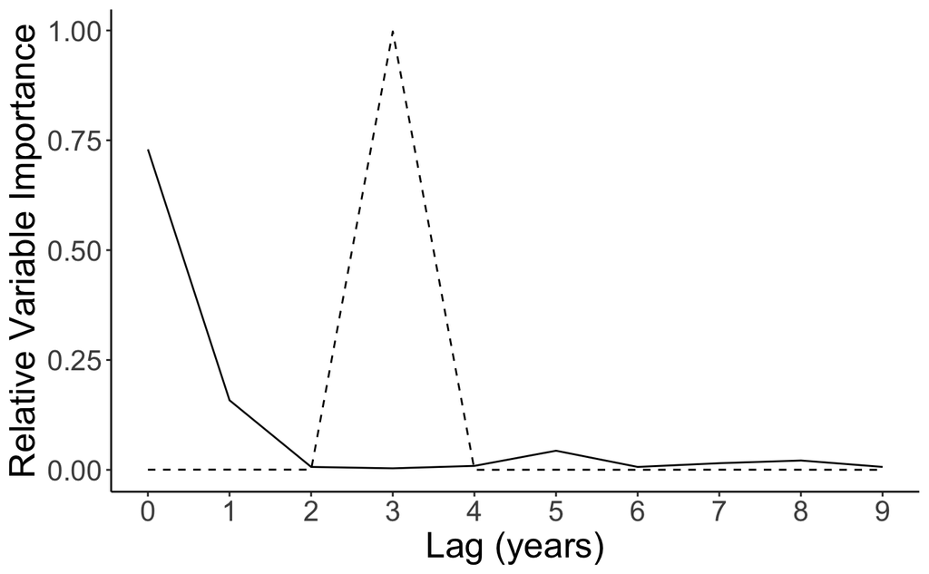

```r
#first, table for lags
lags_RVI_scaled <- data.table(gain_lag = c(0:9), gain_RVI = 0, loss_RVI = 0)

#gains
lags_RVI_scaled[1,2] <- 1-sum(gain_model_comparison_taxonomy[grep("lag", variable), ]$akaike_weight)
lags_RVI_scaled[2,2] <- sum(gain_model_comparison_taxonomy[grep("lag1", variable), ]$akaike_weight)
lags_RVI_scaled[3,2] <- sum(gain_model_comparison_taxonomy[grep("lag2", variable), ]$akaike_weight)
lags_RVI_scaled[4,2] <- sum(gain_model_comparison_taxonomy[grep("lag3", variable), ]$akaike_weight)
lags_RVI_scaled[5,2] <- sum(gain_model_comparison_taxonomy[grep("lag4", variable), ]$akaike_weight)
lags_RVI_scaled[6,2] <- sum(gain_model_comparison_taxonomy[grep("lag5", variable), ]$akaike_weight)
lags_RVI_scaled[7,2] <- sum(gain_model_comparison_taxonomy[grep("lag6", variable), ]$akaike_weight)
lags_RVI_scaled[8,2] <- sum(gain_model_comparison_taxonomy[grep("lag7", variable), ]$akaike_weight)
lags_RVI_scaled[9,2] <- sum(gain_model_comparison_taxonomy[grep("lag8", variable), ]$akaike_weight)
lags_RVI_scaled[10,2] <- sum(gain_model_comparison_taxonomy[grep("lag9", variable), ]$akaike_weight)

#losss
lags_RVI_scaled[1,3] <- 1-sum(loss_model_comparison_taxonomy[grep("lag", variable), ]$akaike_weight)
lags_RVI_scaled[2,3] <- sum(loss_model_comparison_taxonomy[grep("lag1", variable), ]$akaike_weight)
lags_RVI_scaled[3,3] <- sum(loss_model_comparison_taxonomy[grep("lag2", variable), ]$akaike_weight)
lags_RVI_scaled[4,3] <- sum(loss_model_comparison_taxonomy[grep("lag3", variable), ]$akaike_weight)
lags_RVI_scaled[5,3] <- sum(loss_model_comparison_taxonomy[grep("lag4", variable), ]$akaike_weight)
lags_RVI_scaled[6,3] <- sum(loss_model_comparison_taxonomy[grep("lag5", variable), ]$akaike_weight)
lags_RVI_scaled[7,3] <- sum(loss_model_comparison_taxonomy[grep("lag6", variable), ]$akaike_weight)
lags_RVI_scaled[8,3] <- sum(loss_model_comparison_taxonomy[grep("lag7", variable), ]$akaike_weight)
lags_RVI_scaled[9,3] <- sum(loss_model_comparison_taxonomy[grep("lag8", variable), ]$akaike_weight)
lags_RVI_scaled[10,3] <- sum(loss_model_comparison_taxonomy[grep("lag9", variable), ]$akaike_weight)

saveRDS(lags_RVI_scaled, here("Model_results","lags_RVI_scaled.rds"))

#visualize lags through time
ggplot(data = lags_RVI_scaled, aes(x = gain_lag)) +
  geom_line(aes(y = gain_RVI), ) +
  geom_line(aes(y = loss_RVI), linetype = "dashed") +
  labs(x = "Lag (years)", y = "Relative Variable Importance") +
  scale_color_discrete() + #how to make a legend
  theme_classic() +
  theme(text = element_text(size = 20)) +
  scale_x_continuous(breaks = c(0:9))
```

Table for RVI data for gain

```r
gain_loss <- c("gain","gain","gain","gain","gain", "gain","gain", "gain", "gain","gain","gain","gain","gain","gain", "gain","gain", "gain", "gain","gain")
type <- c("Depth", "Depth", "lag", "lag", "Transformation", "Transformation", "Transformation", "Metric", "Metric", "Metric", "Transformation x Metric", "Transformation x Metric", "Transformation x Metric", "Transformation x Metric", "Transformation x Metric", "Transformation x Metric", "Transformation x Metric", "Transformation x Metric", "Transformation x Metric")
variable <- c("Bottom", "Surface", "no_lag", "lagged", "|Change|", "Change", "Raw", "Min", "Max", "Seas", "Raw x Min", "Raw x Max", "Raw x Seas", "Change x Min", "Change x Max", "Change x Seas", "|Change| x Min", "|Change| x Max", "|Change| x Seas")


value <- c(gain_bottom_importance, gain_surface_importance, gain_nolag_importance, gain_lag_importance, gain_abs_importance, gain_change_importance, gain_raw_importance, gain_min_temp_importance, gain_max_temp_importance, gain_seas_temp_importance, gain_raw_min_importance, gain_raw_max_importance, gain_raw_seas_importance, gain_change_min_importance, gain_change_max_importance, gain_change_seas_importance, gain_abs_change_min_importance, gain_abs_change_max_importance, gain_abs_change_seas_importance)

RVI_gain <- data.table(gain_loss, type, variable, value)
```

Table for RVI data for loss

```r
gain_loss <- c("loss","loss","loss","loss","loss", "loss","loss", "loss", "loss","loss","loss","loss","loss","loss", "loss","loss", "loss", "loss","loss")
type <- c("Depth", "Depth", "lag", "lag", "Transformation", "Transformation", "Transformation", "Metric", "Metric", "Metric", "Transformation x Metric", "Transformation x Metric", "Transformation x Metric", "Transformation x Metric", "Transformation x Metric", "Transformation x Metric", "Transformation x Metric", "Transformation x Metric", "Transformation x Metric")
variable <- c("Bottom", "Surface", "no_lag", "lagged", "|Change|", "Change", "Raw", "Min", "Max", "Seas", "Raw x Min", "Raw x Max", "Raw x Seas", "Change x Min", "Change x Max", "Change x Seas", "|Change| x Min", "|Change| x Max", "|Change| x Seas")
value <- c(loss_bottom_importance, loss_surface_importance, loss_nolag_importance, loss_lag_importance, loss_abs_importance, loss_change_importance, loss_raw_importance, loss_min_temp_importance, loss_max_temp_importance, loss_seas_temp_importance, loss_raw_min_importance, loss_raw_max_importance, loss_raw_seas_importance, loss_change_min_importance, loss_change_max_importance, loss_change_seas_importance, loss_abs_change_min_importance, loss_abs_change_max_importance, loss_abs_change_seas_importance)

RVI_loss <- data.table(gain_loss, type, variable, value)
```

Merge RVI tables for gain and loss, and then graph

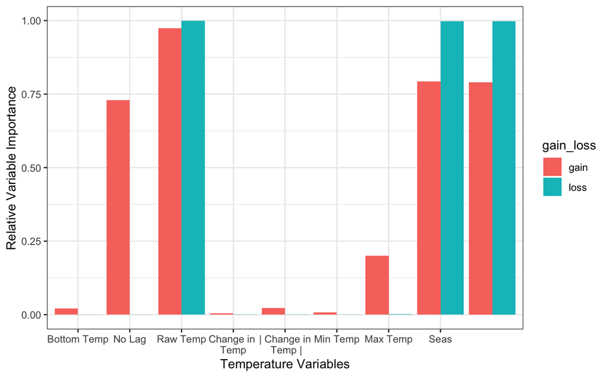

```r
RVI_table <- as.data.table(rbind(RVI_gain, RVI_loss)) #bind RVI for gains and losss

RVI_table.r <- RVI_table[!grep("Surface", variable)][!grep("lagged", variable)]

#change order of factor levels
RVI_table.r[, variable := factor(variable, levels = c("Bottom", "no_lag", "Raw", "Change", "|Change|", "Min", "Max", "Seas"))]

saveRDS(RVI_table, file = here("Model_results", "RVI_table.rds"))

ggplot(data = RVI_table.r, aes(x=variable, y = value, fill = gain_loss)) +
  geom_bar(stat = "identity", position = "dodge") +
  scale_x_discrete(breaks = c("Bottom", "no_lag", "Raw", "Change", "|Change|", "Min", "Max", "Seas"),
                   labels = c("Bottom Temp", "No Lag", "Raw Temp", "Change in \nTemp", "| Change in\n Temp |", "Min Temp", "Max Temp", "Seas")) +
  labs(x = "Temperature Variables", y = "Relative Variable Importance")  +
  theme_bw()
```

Another way to visualize is stacked bar plot.

```r
#put levels into correct order for viewing, and add dummy level for legend
RVI_gain[, variable := factor(variable, levels = c("Bottom", "Surface","  ", "Raw", "Change", "|Change|","", "no_lag", "lagged", "Min", "Max", "Seas"))]
RVI_gain[, type := factor(type, levels = c("Depth", "Transformation", "Metric", "lag"))]

RVI_gain_nolag <- RVI_gain[type != "lag",]
RVI_gain_nolag[, type := factor(type, levels = c("Depth", "Transformation", "Metric"))][, variable := factor(variable, levels = c("Bottom", "Surface","  ", "Raw", "Change", "|Change|","", "Min", "Max", "Seas"))]

saveRDS(RVI_gain_nolag, here("Model_results", "RVI_gain_nolag.rds"))

#and again for loss
RVI_loss[, variable := factor(variable, levels = c("Bottom", "Surface","  ", "Raw", "Change", "|Change|","", "no_lag", "lagged", "Min", "Max", "Seas"))]
RVI_loss[, type := factor(type, levels = c("Depth", "Transformation", "Metric", "lag"))]

RVI_loss_nolag <- RVI_loss[type != "lag",]
RVI_loss_nolag[, type := factor(type, levels = c("Depth", "Transformation", "Metric"))][, variable := factor(variable, levels = c("Bottom", "Surface","  ", "Raw", "Change", "|Change|","", "Min", "Max", "Seas"))]

saveRDS(RVI_loss_nolag, here("Model_results", "RVI_loss_nolag.rds"))


#plotting
pal <- wes_palette("GrandBudapest1", 8, type = "continuous")
colors <- c(pal[1], pal[2], "#FFFFFF", pal[3], pal[4], pal[5],"#FFFFFF", pal[6], pal[7], pal[8])

#gains
RVI_gain_plot <- ggplot(data = RVI_gain_nolag, aes(x=type, y = value, fill = variable)) +
  geom_bar(stat="identity", color = "black", size = 0, width = 0.8) +
  scale_x_discrete(breaks = c("Depth", "Transformation", "Metric"), labels = c("Depth", "Transformation", "Metric")) +
  labs(x = "Temperature Variables", y = "Relative Variable Importance") +
  theme_classic() +
  theme(text = element_text(size = 11.5),
        legend.position = "right",
        legend.title = element_blank(),
        legend.spacing.x = unit(0.2, 'cm'),
        legend.justification = "center",
        aspect.ratio = (1),
        #, legend.position = "none"
        ) +
  guides(fill=guide_legend(ncol=1)) +
  scale_fill_manual(values = colors,
                    drop = F)

#loss
RVI_loss_plot <- ggplot(data = RVI_loss_nolag, aes(x=type, y = value, fill = variable)) +
  geom_bar(stat="identity", color = "black", size = 0, width = 0.8) +
  scale_x_discrete(breaks = c("Depth", "Transformation", "Metric"), labels = c("Depth", "Transformation", "Metric")) +
  labs(x = "Temperature Variables", y = "Relative Variable Importance") +
  theme_classic() +
  theme(text = element_text(size = 11.5),
        legend.position = "right",
        legend.title = element_blank(),
        legend.spacing.x = unit(0.2, 'cm'),
        legend.justification = "center",
        aspect.ratio = (1),
        #, legend.position = "none"
        ) +
  guides(fill=guide_legend(ncol=1)) +
  scale_fill_manual(values = colors,
                    drop = F)

RVI_table
```

| gain_loss | type | variable | value |
| --- | --- | --- | --- |
| gain | Depth | Bottom | 2.165767e-02 |
| gain | Depth | Surface | 9.782774e-01 |
| gain | lag | no_lag | 7.294064e-01 |
| gain | lag | lagged | 2.705936e-01 |
| gain | Transformation | \|Change\| | 2.186612e-02 |
| gain | Transformation | Change | 4.727204e-03 |
| gain | Transformation | Raw | 9.734067e-01 |
| gain | Metric | Min | 7.061408e-03 |
| gain | Metric | Max | 1.998004e-01 |
| gain | Metric | Seas | 7.930732e-01 |

[output cut: 28 more lines]

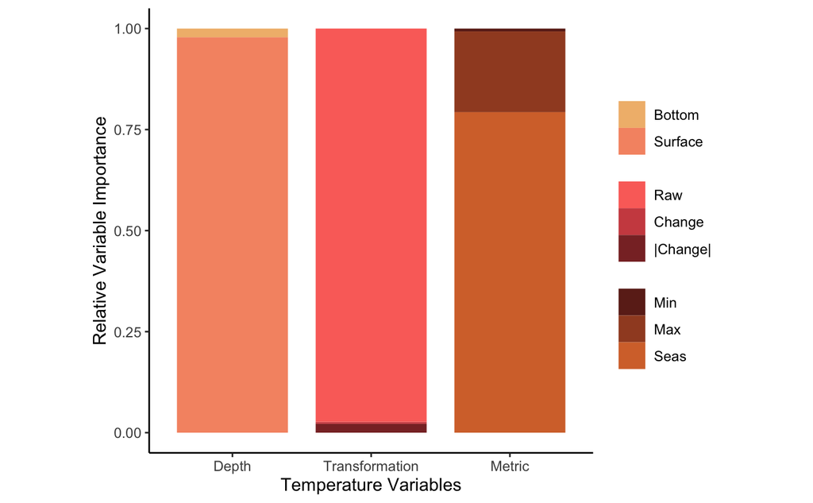

```r
RVI_gain_plot
```

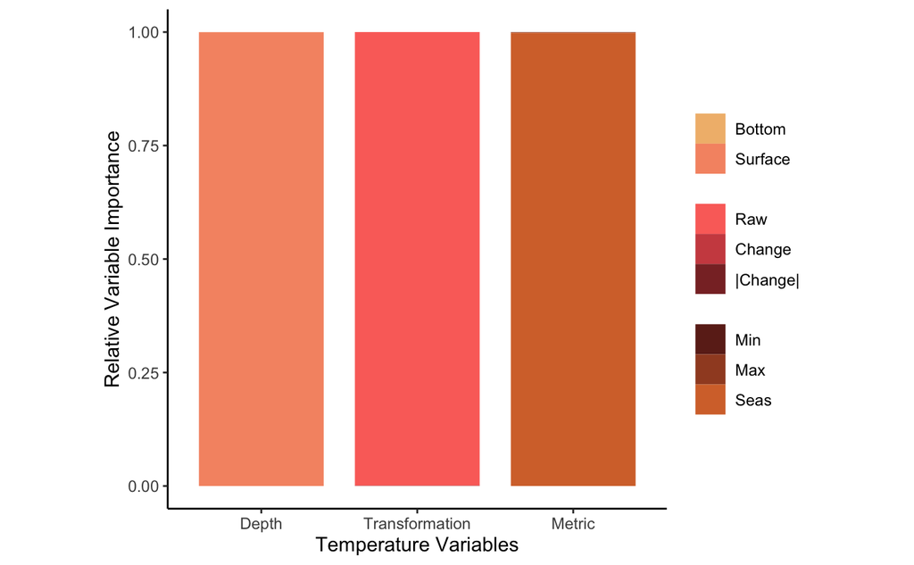

```r
RVI_loss_plot
```

Next step is to add the coefficients on to the bar chart. To do this, I will need to sum (aikake weight of model including variable x coefficient). I think this will be easy enough Using gain_model_comparison_taxonomy data frame. I will add new column to data frame of aikaike weight x coefficient

```r
#for some reason the coefficient is a factor
gain_model_comparison_taxonomy[,coef_num := as.numeric(as.character(coef))]
gain_model_comparison_taxonomy[,aw_coef := akaike_weight * coef_num]

#bottom temperature avg coefficient
gain_bottom_temp_avg_coef <- sum(gain_model_comparison_taxonomy[grep("sbt", variable)]$coef_num)

#surface temperature avg coefficient
gain_surface_temp_avg_coef <- sum(gain_model_comparison_taxonomy[grep("sst", variable)]$coef_num)

#raw seasonality avg coefficient
gain_seas_raw_avg_coef <-
  sum(gain_model_comparison_taxonomy[grep("seas", variable), ][!grep("change", variable)]$coef_num)

#max abs change avg coefficient
gain_max_abs_change_avg_coef <-
  sum(gain_model_comparison_taxonomy[grep("max_s.t_temp_change_abs", variable), ]$coef_num)
```

```r
#for some reason the coefficient is a factor
loss_model_comparison_taxonomy[,coef_num := as.numeric(as.character(coef))]
loss_model_comparison_taxonomy[,aw_coef := akaike_weight * coef_num]

#bottom temperature avg coefficient
loss_bottom_temp_avg_coef <- sum(loss_model_comparison_taxonomy[grep("sbt", variable)]$coef_num)

#surface temperature avg coefficient
loss_surface_temp_avg_coef <- sum(loss_model_comparison_taxonomy[grep("sst", variable)]$coef_num)

#raw seasonality avg coefficient
loss_seas_raw_avg_coef <-
  sum(loss_model_comparison_taxonomy[grep("seas", variable), ][!grep("change", variable)]$coef_num)

#min change avg coefficient
loss_min_abs_change_avg_coef <-
  sum(loss_model_comparison_taxonomy[grep("min_s.t_temp_change", variable), ][!grep("abs", variable)]$coef_num)

#seas change avg coefficient
loss_seas_change_avg_coef <-
  sum(loss_model_comparison_taxonomy[grep("seas_s.t_temp_change", variable), ][!grep("abs", variable)]$coef_num)
```

```r
#list of fish names from trait database
traits <- fread("TraitCollectionFishNAtlanticNEPacificContShelf (3).csv")
```

[output not shown]

loss Models without Traits

Relative Variable Importance

Relative Variable Importance for gain Models

Relative Variable Importance for loss Models

Let’s see how the RVI importance varies by looking at specific lag values

Table for RVI data for gain

Table for RVI data for loss

Merge RVI tables for gain and loss, and then graph

Another way to visualize is stacked bar plot.